# Integració i Neteja de dades en el fitxer train.csv

ANNA SERENA LATRE / XAVIER JORDÀ MURRIA

17 maig de 2019

El fitxer train comta amb 891 files i 12 columnes.

```r
# train datasaet dimensions.
dim(train)
```

```
## [1] 891  12
```

Els noms de les 12 variables són:

```r
# train dataset variables names:
names(train)
```

```
##  [1] "PassengerId" "Survived"    "Pclass"      "Name"        "Sex"
##  [6] "Age"         "SibSp"       "Parch"       "Ticket"      "Fare"
## [11] "Cabin"       "Embarked"
```

La tipologia de les dades en les variables és:

```r
# train data type:
str(train)
```

```
## Classes 'spec_tbl_df', 'tbl_df', 'tbl' and 'data.frame': 891 obs. of  12 variables:
##  $ PassengerId: num  1 2 3 4 5 6 7 8 9 10 ...
##  $ Survived   : num  0 1 1 1 0 0 0 0 1 1 ...
##  $ Pclass     : num  3 1 3 1 3 3 1 3 3 2 ...
##  $ Name       : chr  "Braund, Mr. Owen Harris" "Cumings, Mrs. John Bradley (Florence Briggs Thayer)" "Heikkinen, Miss. Laina" "Futrelle, Mrs. Jacques Heath (Lily May Peel)" ...
##  $ Sex        : chr  "male" "female" "female" "female" ...
##  $ Age        : num  22 38 26 35 35 NA 54 2 27 14 ...
##  $ SibSp      : num  1 1 0 1 0 0 0 3 0 1 ...
##  $ Parch      : num  0 0 0 0 0 0 0 1 2 0 ...
##  $ Ticket     : chr  "A/5 21171" "PC 17599" "STON/O2. 3101282" "113803" ...
##  $ Fare       : num  7.25 71.28 7.92 53.1 8.05 ...
##  $ Cabin      : chr  NA "C85" NA "C123" ...
##  $ Embarked   : chr  "S" "C" "S" "S" ...
##  - attr(*, "spec")=
##   .. cols(
##   ..   PassengerId = col_double(),
##   ..   Survived = col_double(),
##   ..   Pclass = col_double(),
##   ..   Name = col_character(),
##   ..   Sex = col_character(),
##   ..   Age = col_double(),
##   ..   SibSp = col_double(),
##   ..   Parch = col_double(),
##   ..   Ticket = col_character(),
##   ..   Fare = col_double(),
##   ..   Cabin = col_character(),
##   ..   Embarked = col_character()
##   .. )
```

Resum numèric amb les dades estadístiques més rellevants:

```r
# Statistical summary for train variables.
summary(train)
```

```
##   PassengerId       Survived          Pclass          Name
##  Min.   :  1.0   Min.   :0.0000   Min.   :1.000   Length:891
##  1st Qu.:223.5   1st Qu.:0.0000   1st Qu.:2.000   Class :character
##  Median :446.0   Median :0.0000   Median :3.000   Mode  :character
##  Mean   :446.0   Mean   :0.3838   Mean   :2.309
##  3rd Qu.:668.5   3rd Qu.:1.0000   3rd Qu.:3.000
##  Max.   :891.0   Max.   :1.0000   Max.   :3.000
##
##      Sex                 Age            SibSp           Parch
##  Length:891         Min.   : 0.42   Min.   :0.000   Min.   :0.0000
##  Class :character   1st Qu.:20.12   1st Qu.:0.000   1st Qu.:0.0000
##  Mode  :character   Median :28.00   Median :0.000   Median :0.0000
##                     Mean   :29.70   Mean   :0.523   Mean   :0.3816
##                     3rd Qu.:38.00   3rd Qu.:1.000   3rd Qu.:0.0000
##                     Max.   :80.00   Max.   :8.000   Max.   :6.0000
##                     NA's   :177
##     Ticket               Fare           Cabin             Embarked
##  Length:891         Min.   :  0.00   Length:891         Length:891
##  Class :character   1st Qu.:  7.91   Class :character   Class :character
##  Mode  :character   Median : 14.45   Mode  :character   Mode  :character
##                     Mean   : 32.20
##                     3rd Qu.: 31.00
##                     Max.   :512.33
##
```

# 1 Integració de dades en el fitxer train.csv.

## 1.1 Supressió de les variables PassengerId i Ticket.

```r
# Variables name display.
names(train)
```

```
##  [1] "PassengerId" "Survived"    "Pclass"      "Name"        "Sex"
##  [6] "Age"         "SibSp"       "Parch"       "Ticket"      "Fare"
## [11] "Cabin"       "Embarked"
```

```r
# Deleting PassengerId and Ticket variables.
Train <- subset(train, select=c(2,3,4,5,6,7,8,10,11,12))
```

## 1.2 Conversió de les variables categòriques a factorial.

*Test factorial:

```r
# Categorical variables factorial test.
is.factor(Train$Survived)
```

```
## [1] FALSE
```

```r
is.factor(Train$Pclass)
```

```
## [1] FALSE
```

```r
is.factor(Train$Sex)
```

```
## [1] FALSE
```

```r
is.factor(Train$SibSp)
```

```
## [1] FALSE
```

```r
is.factor(Train$Parch)
```

```
## [1] FALSE
```

```r
is.factor(Train$Cabin)
```

```
## [1] FALSE
```

```r
is.factor(Train$Embarked)
```

```
## [1] FALSE
```

Ho hi ha cap variable categòrica a factor.

*Factorialització:

```r
# Categorical variables factorization.
Train$Survived <- as.factor(Train$Survived)
Train$Pclass <- as.factor(Train$Pclass)
Train$Sex <- as.factor(Train$Sex)
Train$SibSp <- as.factor(Train$SibSp)
Train$Parch <- as.factor(Train$Parch)
Train$Cabin <- as.factor(Train$Cabin)
Train$Embarked <- as.factor(Train$Embarked)
```

*Factorialització:

```r
# Categorical variables factorization.

Train$Pclass <- as.factor(Train$Pclass)
```

# 2 Neteja de dades: Fitxer train.csv.

## 2.1 Casos de duplicats:

```r
# Duplicated cases:
table(duplicated(Train))
```

```
##
## FALSE
##   891
```

No hi ha casos de duplicats en el dataset Train.

## 2.2 Valoració i gestió dels valors NA.

```r
#  Detecting Na values:
apply(Train, 2, function(x) any(is.na(x)))
```

```
## Survived   Pclass     Name      Sex      Age    SibSp    Parch     Fare
##    FALSE    FALSE    FALSE    FALSE     TRUE    FALSE    FALSE    FALSE
##    Cabin Embarked
##     TRUE     TRUE
```

Hi ha tres variables amb valors NA, la variable Age, Cabin i Embarked.

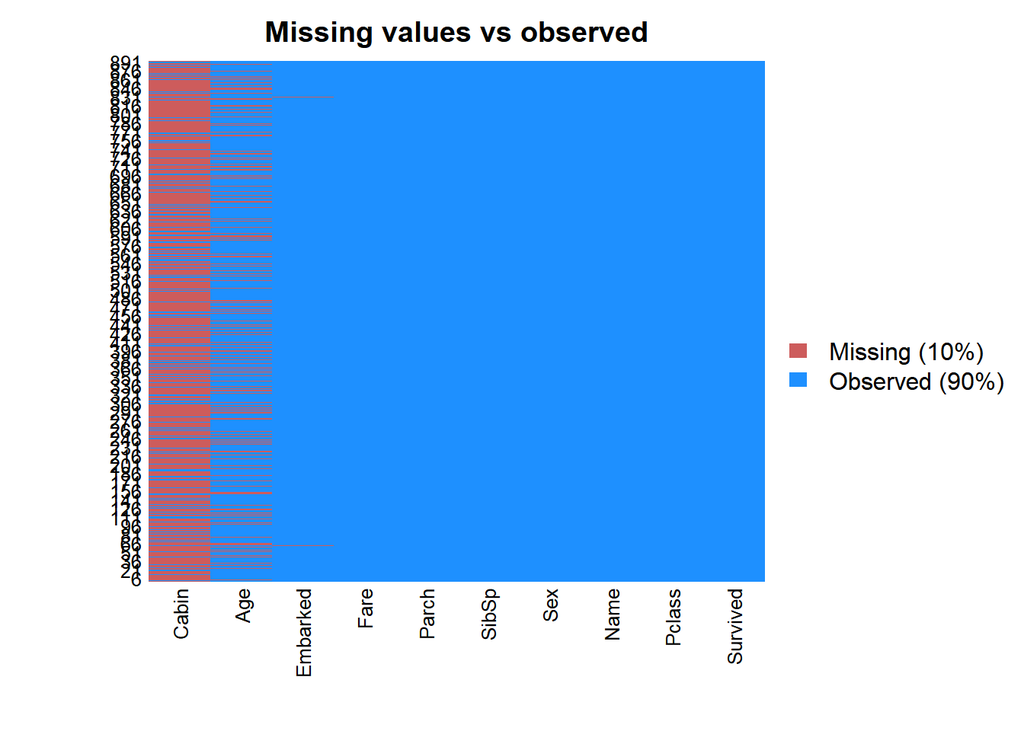

```r
# Amelia software package.
library(Amelia)
# missmap function for
missmap(Train, main = "Missing values vs observed")
```

En el gràfic observem com la variable **Cabin** es troba fortament afectada per la presència de valors NA i optarem per la seva supressió directa.

La variable **Age** també es troba afectada per la presència de valors NA que intentarem reemplaçar per la mitja o bé knn.

La variable **Embarked** es troba molt poc afectada per la presència de valors NA i procedirem a la supressió de les files en les observacions que els contenen.

**Supressió de la variable Cabin i Name;**

```r
names(Train)
```

```
##  [1] "Survived" "Pclass"   "Name"     "Sex"      "Age"      "SibSp"
##  [7] "Parch"    "Fare"     "Cabin"    "Embarked"
```

```r
# Deleting cabin variable.
Train <- subset(Train, select=c(1,2,4,5,6,7,8,10))
```

Suprimim aquí la variable Name perquè ens ha estat útil en la identificació de duplicats innecessaris.

```r
# Train variable names display.
names(Train)
```

```
## [1] "Survived" "Pclass"   "Sex"      "Age"      "SibSp"    "Parch"
## [7] "Fare"     "Embarked"
```

**Reemplaçament dels valors NA per la mitja;**

```r
# Mean placing NA values on Age variable.
Train$Age[is.na(Train$Age)] <- mean(Train$Age, na.rm = T)
```

**Supressió de les files amb valors NA en la variable Embarked;**

```r
# Deleting Embarked rows with NA values.
Train <- Train[!is.na(Train$Embarked),]
rownames(Train) <- NULL
```